# Tarea 7 - Montenegro Maximiliano

# Obtención de la función transferencia general

La estructura puede dividirse en tres etapas:

$$ H(z)=H_1(z)\,H_2(z)\,H_3(z) $$

## 1. Primera etapa

El primer bloque del sistema se representa mediante el siguiente diagrama:

[figure not shown]

A partir de la primera sección:

$$ y_1(n)=x(n)-c_1x(n-N) $$

Aplicando transformada Z:

$$ Y_1(z)=X(z)-c_1z^{-N}X(z) $$

Sacando factor común $X(z)$:

$$ Y_1(z)=X(z)\left(1-c_1z^{-N}\right) $$

Por lo tanto:

$$ H_1(z)=\frac{Y_1(z)}{X(z)} $$

y se obtiene:

$$ \boxed{H_1(z)=1-c_1z^{-N}} $$

## 2. Segunda etapa

La sección recursiva del sistema se encuentra dentro de la siguiente estructura:

[figure not shown]

Para la sección recursiva se define la señal interna $t(n)$ como:

$$ t(n)=a_0\left[y_1(n)+a_1t(n-1)+a_2t(n-2)\right] $$

Aplicando transformada Z:

$$ T(z)=a_0\left[ Y_1(z) +a_1z^{-1}T(z) +a_2z^{-2}T(z) \right] $$

Distribuyendo $a_0$:

$$ T(z) = a_0Y_1(z) + a_0a_1z^{-1}T(z) + a_0a_2z^{-2}T(z) $$

Agrupando los términos que contienen $T(z)$:

$$ T(z) -a_0a_1z^{-1}T(z) -a_0a_2z^{-2}T(z) = a_0Y_1(z) $$

Sacando factor común $T(z)$:

$$ T(z) \left( 1-a_0a_1z^{-1}-a_0a_2z^{-2} \right) = a_0Y_1(z) $$

Por lo tanto:

$$ H_2(z) = \frac{T(z)}{Y_1(z)} = \frac{a_0} {1-a_0a_1z^{-1}-a_0a_2z^{-2}} $$

Dividiendo numerador y denominador por $a_0$:

$$ \boxed{ H_2(z) = \frac{1} {\frac{1}{a_0}-a_1z^{-1}-a_2z^{-2}} } $$

## 3. Tercera etapa

La salida se obtiene como:

$$ y(n) = b_0t(n) +b_1t(n-1) +b_2t(n-2) $$

Aplicando transformada Z:

$$ Y(z) = b_0T(z) +b_1z^{-1}T(z) +b_2z^{-2}T(z) $$

Sacando factor común $T(z)$:

$$ Y(z) = T(z) \left( b_0+b_1z^{-1}+b_2z^{-2} \right) $$

Por lo tanto:

$$ H_3(z) = \frac{Y(z)}{T(z)} $$

y resulta:

$$ \boxed{ H_3(z) = b_0+b_1z^{-1}+b_2z^{-2} } $$

# Función transferencia total

Como las tres etapas se encuentran en cascada:

$$ H(z)=H_1(z)H_2(z)H_3(z) $$

También puede escribirse:

$$ H(z) = \frac{Y_1(z)}{X(z)} \frac{T(z)}{Y_1(z)} \frac{Y(z)}{T(z)} $$

Cancelando los términos intermedios:

$$ H(z)=\frac{Y(z)}{X(z)} $$

Finalmente:

$$ \boxed{ H(z)= \left(1-c_1z^{-N}\right) \frac{ b_0+b_1z^{-1}+b_2z^{-2} }{ \frac{1}{a_0}-a_1z^{-1}-a_2z^{-2} } } $$

# Filtro Media Móvil

[figure not shown]

La función transferencia de un filtro media móvil de longitud $N$ puede escribirse como:

$$ H(z)=\frac{1}{N}\sum_{k=0}^{N-1}z^{-k} $$

La sumatoria corresponde a una serie geométrica finita:

$$ 1+z^{-1}+z^{-2}+\cdots+z^{-(N-1)} $$

Utilizando la expresión general:

$$ \sum_{k=0}^{N-1}r^k = \frac{1-r^N}{1-r} $$

y tomando:

$$ r=z^{-1} $$

se obtiene:

$$ \sum_{k=0}^{N-1}z^{-k} = \frac{1-z^{-N}}{1-z^{-1}} $$

Por lo tanto:

$$ \boxed{ H(z)= \frac{1}{N} \frac{1-z^{-N}} {1-z^{-1}} } $$

Esta expresión también puede escribirse desarrollando la suma:

$$ \boxed{ H(z)= \frac{1}{N} \left( 1+z^{-1}+z^{-2}+\cdots+z^{-(N-1)} \right) } $$

# Casos particulares

## Para $N=3$

$$ H_3(z) = \frac{1}{3} \left( 1+z^{-1}+z^{-2} \right) $$

Por lo tanto:

$$ \boxed{ H_3(z) = \frac{1}{3} \left( 1+z^{-1}+z^{-2} \right) } $$

## Para $N=4$

$$ H_4(z) = \frac{1}{4} \left( 1+z^{-1}+z^{-2}+z^{-3} \right) $$

Por lo tanto:

$$ \boxed{ H_4(z) = \frac{1}{4} \left( 1+z^{-1}+z^{-2}+z^{-3} \right) } $$

## Para $N=5$

$$ H_5(z) = \frac{1}{5} \left( 1+z^{-1}+z^{-2}+z^{-3}+z^{-4} \right) $$

Por lo tanto:

$$ \boxed{ H_5(z) = \frac{1}{5} \left( 1+z^{-1}+z^{-2}+z^{-3}+z^{-4} \right) } $$

# Resumen

$$ \boxed{ H_N(z)= \frac{1}{N} \sum_{k=0}^{N-1}z^{-k} } $$

con:

$$ \boxed{ H_3(z)= \frac{1}{3} \left( 1+z^{-1}+z^{-2} \right) } $$

$$ \boxed{ H_4(z)= \frac{1}{4} \left( 1+z^{-1}+z^{-2}+z^{-3} \right) } $$

$$ \boxed{ H_5(z)= \frac{1}{5} \left( 1+z^{-1}+z^{-2}+z^{-3}+z^{-4} \right) } $$

```
Ignoring fixed y limits to fulfill fixed data aspect with adjustable data limits.
Ignoring fixed y limits to fulfill fixed data aspect with adjustable data limits.
```

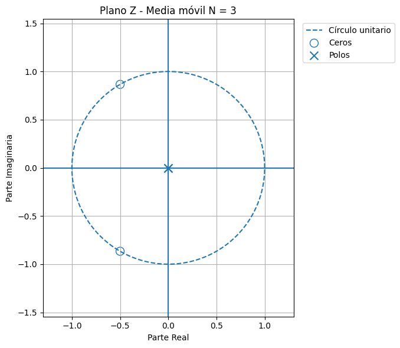

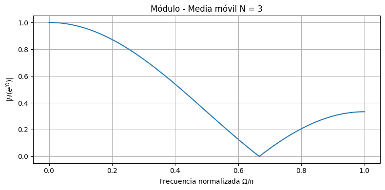

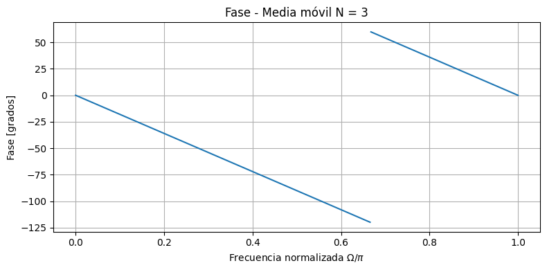

```
Ignoring fixed y limits to fulfill fixed data aspect with adjustable data limits.
Ignoring fixed y limits to fulfill fixed data aspect with adjustable data limits.
```

```
=======================================================
FILTRO MEDIA MÓVIL - N = 3
=======================================================

CEROS:

Cero 1:
z = -0.5000 +0.8660j
|z| = 1.0000
Fase = 2.0944 rad
Fase = 120.00°

Cero 2:
z = -0.5000 -0.8660j
|z| = 1.0000
Fase = -2.0944 rad
Fase = -120.00°

POLOS:

Polo 1:
z = 0.0000 +0.0000j
|z| = 0.0000
Fase = indefinida (polo en el origen)

Polo 2:
z = 0.0000 +0.0000j
|z| = 0.0000
Fase = indefinida (polo en el origen)
```

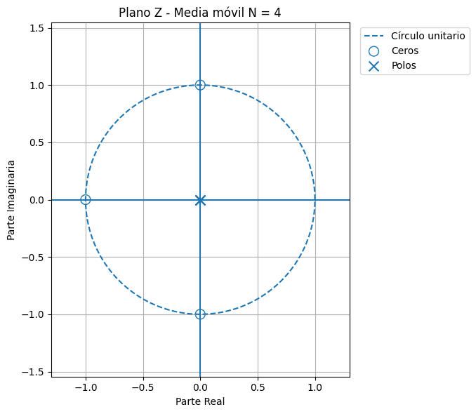

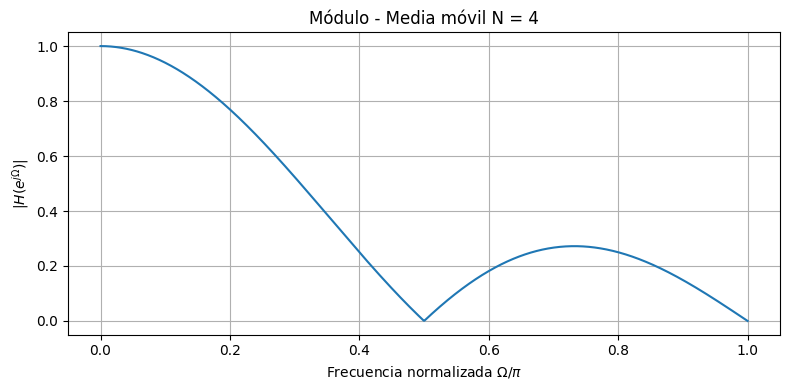

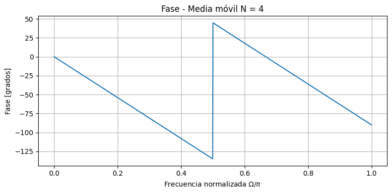

```
Ignoring fixed y limits to fulfill fixed data aspect with adjustable data limits.
Ignoring fixed y limits to fulfill fixed data aspect with adjustable data limits.
```

```
=======================================================
FILTRO MEDIA MÓVIL - N = 4
=======================================================

CEROS:

Cero 1:
z = -1.0000 +0.0000j
|z| = 1.0000
Fase = 3.1416 rad
Fase = 180.00°

Cero 2:
z = -0.0000 +1.0000j
|z| = 1.0000
Fase = 1.5708 rad
Fase = 90.00°

Cero 3:
z = -0.0000 -1.0000j
|z| = 1.0000
Fase = -1.5708 rad
Fase = -90.00°

POLOS:

Polo 1:
z = 0.0000 +0.0000j
|z| = 0.0000
Fase = indefinida (polo en el origen)

Polo 2:
z = 0.0000 +0.0000j
|z| = 0.0000
Fase = indefinida (polo en el origen)

Polo 3:
z = 0.0000 +0.0000j
|z| = 0.0000
Fase = indefinida (polo en el origen)
```

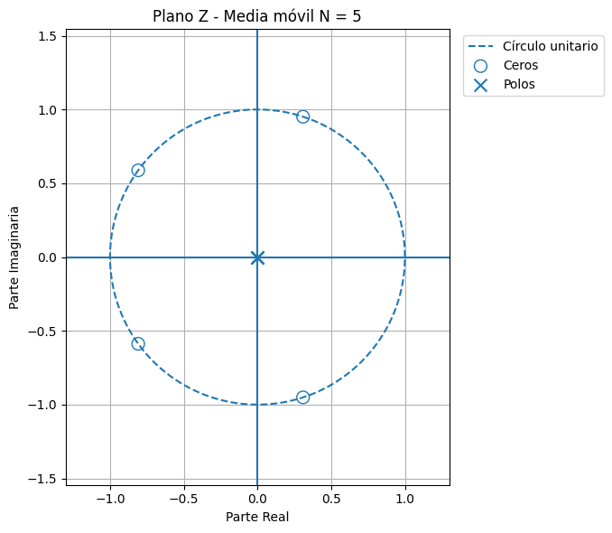

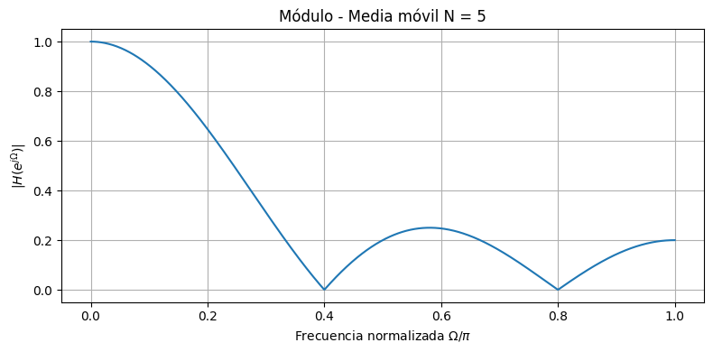

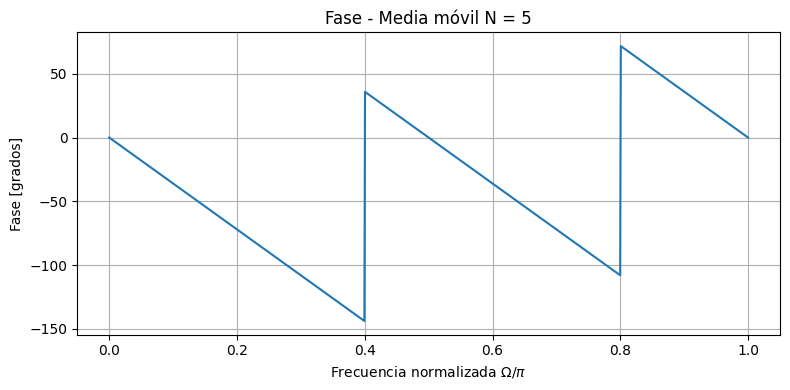

```
=======================================================
FILTRO MEDIA MÓVIL - N = 5
=======================================================

CEROS:

Cero 1:
z = 0.3090 +0.9511j
|z| = 1.0000
Fase = 1.2566 rad
Fase = 72.00°

Cero 2:
z = 0.3090 -0.9511j
|z| = 1.0000
Fase = -1.2566 rad
Fase = -72.00°

Cero 3:
z = -0.8090 +0.5878j
|z| = 1.0000
Fase = 2.5133 rad
Fase = 144.00°

Cero 4:
z = -0.8090 -0.5878j
|z| = 1.0000
Fase = -2.5133 rad
Fase = -144.00°

POLOS:

Polo 1:
z = 0.0000 +0.0000j
|z| = 0.0000
Fase = indefinida (polo en el origen)

Polo 2:
z = 0.0000 +0.0000j
|z| = 0.0000
Fase = indefinida (polo en el origen)

Polo 3:
z = 0.0000 +0.0000j
|z| = 0.0000
Fase = indefinida (polo en el origen)

Polo 4:
z = 0.0000 +0.0000j
|z| = 0.0000
Fase = indefinida (polo en el origen)
```

# Filtro diferenciador

[figure not shown]

La función transferencia deseada es:

$$ H(z)=\frac{1-z^{-2}}{2} $$

También puede escribirse como:

$$ \boxed{ H(z)=\frac{1}{2}\left(1-z^{-2}\right) } $$

A partir de la ecuación temporal:

$$ y(n)=\frac{x(n)-x(n-2)}{2} $$

Aplicando transformada Z:

$$ Y(z)=\frac{1}{2}\left[X(z)-z^{-2}X(z)\right] $$

Sacando factor común $X(z)$:

$$ Y(z)=X(z)\frac{1}{2}\left(1-z^{-2}\right) $$

Por lo tanto:

$$ H(z)=\frac{Y(z)}{X(z)} $$

y resulta:

$$ \boxed{ H(z)=\frac{1}{2}\left(1-z^{-2}\right) } $$

## Coeficientes de la topología

Comparando con la función transferencia general:

$$ H(z)= \left(1-c_1z^{-N}\right) \frac{ b_0+b_1z^{-1}+b_2z^{-2} }{ \frac{1}{a_0}-a_1z^{-1}-a_2z^{-2} } $$

Para implementar el diferenciador de forma directa se puede tomar:

$$ c_1=0 $$

$$ a_0=1 $$

$$ a_1=a_2=0 $$

y:

$$ b_0=\frac{1}{2} $$

$$ b_1=0 $$

$$ b_2=-\frac{1}{2} $$

Por lo tanto:

$$ \boxed{ a_0=1,\quad a_1=a_2=0,\quad b_0=\frac12,\quad b_1=0,\quad b_2=-\frac12,\quad c_1=0 } $$

```
Ignoring fixed y limits to fulfill fixed data aspect with adjustable data limits.
Ignoring fixed y limits to fulfill fixed data aspect with adjustable data limits.
```

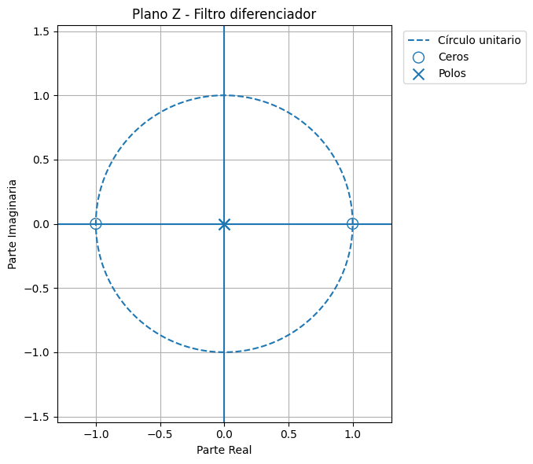

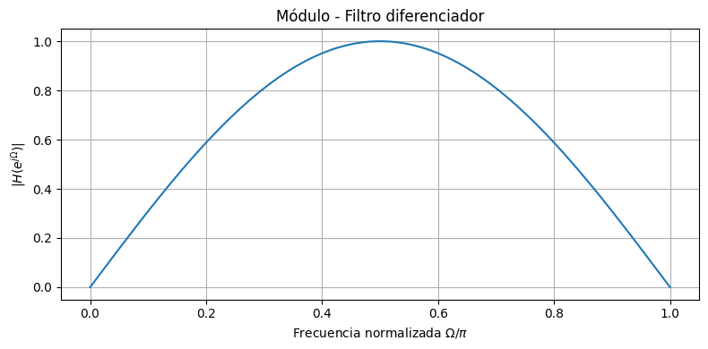

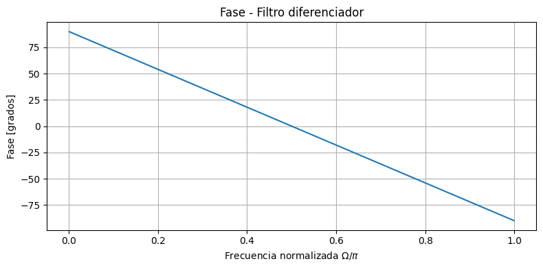

```
=======================================================
FILTRO DIFERENCIADOR
=======================================================

CEROS:

Cero 1:
z = -1.0000 +0.0000j
|z| = 1.0000
Fase = 3.1416 rad
Fase = 180.00°

Cero 2:
z = 1.0000 +0.0000j
|z| = 1.0000
Fase = 0.0000 rad
Fase = 0.00°

POLOS:

Polo 1:
z = 0.0000 +0.0000j
|z| = 0.0000
Fase = indefinida (polo en el origen)

Polo 2:
z = 0.0000 +0.0000j
|z| = 0.0000
Fase = indefinida (polo en el origen)
```

## Verificación del diferenciador mediante Python

Se evalúa el sistema:

$$ y[n]=\frac{x[n]-x[n-2]}{2} $$

utilizando como entrada una señal sinusoidal discreta:

$$ x[n]=\sin(\Omega_0 n) $$

con:

$$ \Omega_0=0.1\pi $$

Finalmente, se compara la salida obtenida con la aproximación numérica de la derivada mediante la función `diff` de Python.

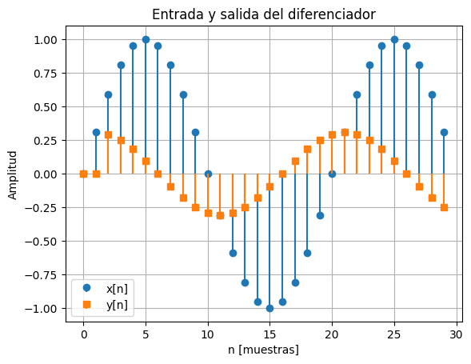

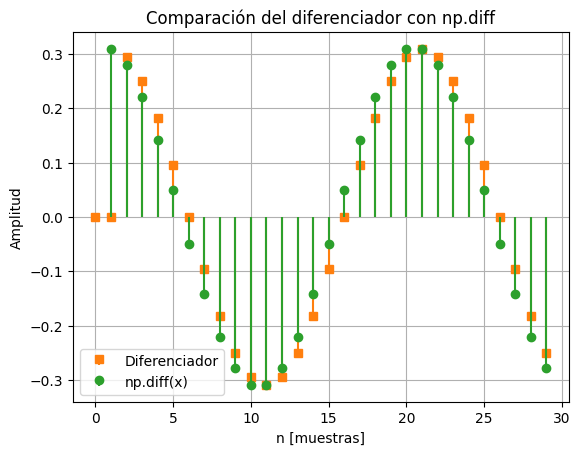

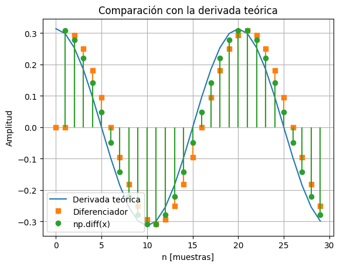

# Filtro Peine

[figure not shown]

Para el filtro peine se tiene:

$$ c_1=-1 $$

y:

$$ N=8 $$

Partiendo de:

$$ H(z)=1-c_1z^{-N} $$

se reemplazan los valores:

$$ H(z)=1-(-1)z^{-8} $$

por lo tanto:

$$ \boxed{ H(z)=1+z^{-8} } $$

Multiplicando numerador y denominador por $z^8$:

$$ H(z) = \frac{z^8+1}{z^8} $$

Por lo tanto:

$$ \boxed{ H(z)= \frac{z^8+1}{z^8} } $$

## Ceros

Los ceros se obtienen de:

$$ z^8+1=0 $$

entonces:

$$ z^8=-1 $$

Como:

$$ -1=e^{j(\pi+2k\pi)} $$

se obtiene:

$$ z_k= e^{j\frac{(2k+1)\pi}{8}} $$

con:

$$ k=0,1,\ldots,7 $$

Por lo tanto:

$$ \boxed{ z_k= e^{j\frac{(2k+1)\pi}{8}} } $$

Todos los ceros tienen módulo:

$$ \boxed{|z_k|=1} $$

por lo tanto se encuentran sobre el círculo unitario.

## Polos

A partir del denominador:

$$ z^8=0 $$

se obtiene:

$$ \boxed{ z=0 } $$

con multiplicidad 8.

## Respuesta en frecuencia

Evaluando sobre el círculo unitario:

$$ z=e^{j\Omega} $$

se obtiene:

$$ H(e^{j\Omega}) = 1+e^{-j8\Omega} $$

Factorizando:

$$ H(e^{j\Omega}) = e^{-j4\Omega} \left( e^{j4\Omega}+e^{-j4\Omega} \right) $$

y utilizando:

$$ e^{jx}+e^{-jx}=2\cos x $$

se obtiene:

$$ \boxed{ H(e^{j\Omega}) = 2\cos(4\Omega)e^{-j4\Omega} } $$

## Módulo

Por lo tanto:

$$ \boxed{ |H(e^{j\Omega})| = 2|\cos(4\Omega)| } $$

Los nulls aparecen cuando:

$$ \cos(4\Omega)=0 $$

por lo tanto:

$$ \boxed{ \Omega_{\text{null}} = \frac{(2k+1)\pi}{8} } $$

En el intervalo:

$$ 0\leq\Omega\leq\pi $$

se obtiene:

$$ \boxed{ \Omega= \frac{\pi}{8}, \frac{3\pi}{8}, \frac{5\pi}{8}, \frac{7\pi}{8} } $$

Los peaks aparecen cuando:

$$ |\cos(4\Omega)|=1 $$

por lo tanto:

$$ \boxed{ \Omega_{\text{peak}} = \frac{k\pi}{4} } $$

## Fase

La respuesta es:

$$ H(e^{j\Omega}) = 2\cos(4\Omega)e^{-j4\Omega} $$

Por lo tanto, cuando:

$$ \cos(4\Omega)>0 $$

la fase es:

$$ \boxed{ \phi(\Omega)=-4\Omega } $$

y cuando:

$$ \cos(4\Omega)<0 $$

el factor real es negativo y agrega una fase de $\pi$:

$$ \boxed{ \phi(\Omega)=-4\Omega+\pi } $$

En los nulls:

$$ |H(e^{j\Omega})|=0 $$

por lo tanto la fase es indefinida.

```
Ignoring fixed y limits to fulfill fixed data aspect with adjustable data limits.
Ignoring fixed y limits to fulfill fixed data aspect with adjustable data limits.
```

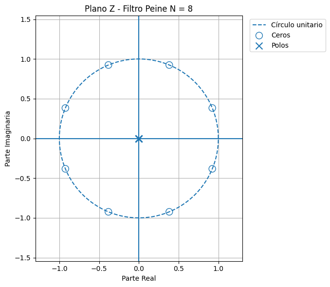

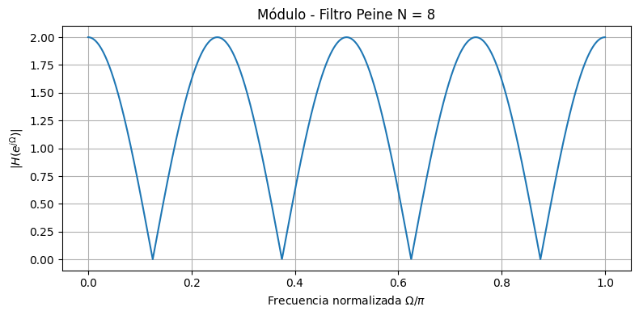

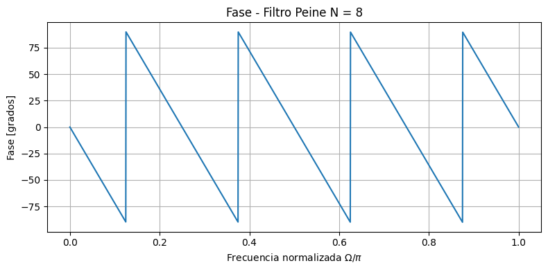

```
=======================================================
FILTRO PEINE - N = 8
=======================================================

CEROS:

Cero 1:
z = -0.9239 -0.3827j
|z| = 1.0000
Fase = -2.7489 rad
Fase = -157.50°

Cero 2:
z = -0.3827 -0.9239j
|z| = 1.0000
Fase = -1.9635 rad
Fase = -112.50°

Cero 3:
z = 0.3827 -0.9239j
|z| = 1.0000
Fase = -1.1781 rad
Fase = -67.50°

Cero 4:
z = 0.9239 -0.3827j
|z| = 1.0000
Fase = -0.3927 rad
Fase = -22.50°

Cero 5:
z = 0.9239 +0.3827j
|z| = 1.0000
Fase = 0.3927 rad
Fase = 22.50°

Cero 6:
z = 0.3827 +0.9239j
|z| = 1.0000
Fase = 1.1781 rad
```

[output cut: 40 more lines]

```

Polo 6:
z = 0.0000 +0.0000j
|z| = 0.0000
Fase = indefinida (polo en el origen)

Polo 7:
z = 0.0000 +0.0000j
|z| = 0.0000
Fase = indefinida (polo en el origen)

Polo 8:
z = 0.0000 +0.0000j
|z| = 0.0000
Fase = indefinida (polo en el origen)
```

# Manuscrito original

El desarrollo realizado a mano se encuentra disponible en el siguiente archivo:

📄 Ver manuscrito completo

[interactive chart not shown]